# Tutorial Análise de Dados do Twitter

Código original: https://github.com/TiagoVentura/tutorial_dapp_day/blob/main/Tutorial_dapp_day_R.rmd

# Acesso a dados do Twitter.

Para acessar a API do Twitter, utilizaremos o pacote rtweet. Nosso primeiro passo é instalar o pacote.

```r
# Ativar rtweet
#install.packages("rtweet") # somente uma vez
library(rtweet)
# ativar outros pacotes
library(tidyverse)
library(igraph)
library(broom)
library(here)
here()
```

```
[1] "/Users/beatrizmilz/GitHub/Pesquisa/2021-SICSS"
```

## Solicitando sua credenciais.

Conforme aprendemos na semana passada, algumas APIs exigem um cadastro prévio para dar a devida autorização para seus acessos a dados. Este é o caso do Twitter. Para solicitar as credenciais, vocÊ precisa: 1) ter uma conta no twitter, 2) criar uma conta de desenvolvedor do twitter. O pacote `rtweet` possui um excelente tutorial sobre como solicitar acesso de desenvolvedor.

```r
# vignette("auth", package = "rtweet")
```

Após receber suas credenciais, você deve fazer seu login. Primeiro vamos criar objetos com nossas chaves.

Agora, vamos liberar nosso acesso.

```r
# create_token(app=app_name,
#              consumer_key=consumer_key,
#              consumer_secret=consumer_secret,
#              access_token = access_token,
#              access_secret = access_token_secret)
```

Pronto. A função create_token salva no seu ambiente do R sua senha de acesso. A priori, se estiver funcionando corretamente, você não precisa repetir essa autorização outras vezes. Para testar, você pode abrir e fechar sua sessão no R para verificar o funcionamento.

```r
rtweet::bearer_token()
```

[output not shown]

## Rest API: Acessar tweets antigos.

O Twitter possui duas API: Rest API e Stream API. Vamos começar com a REST API. Esta API permite:

- Acesso a tweets dos últimos 6-9 dias.
- 18.000 tweets em cada acesso de 15 minutos.

Para usar esta função, você precisa entrar um termo de busca. A busca avançada no Twitter ajuda a formatar os termos de busca adequados quando seu interesse está em mais de uma simples palavras.

```r
# Carregar os dados que baixei antes aqui.
# load("tutorial_twitter.RData")
```

```r
# Recentemente o argumento retryonratelimit não tem funcionado com minhas credenciais.
# Abri um issue no github, mas não foi resolvido.
# Então caso vocês tenham o mesmo problema, uma possível solução seria
# escrever um loop. Ou usar o twarc em Python para coletar dados e depois fazer as análises em R.
tweets_prime <-search_tweets("primeday OR (prime AND day) OR amazon OR (jeff AND bezos) OR #primeday OR #primeday2021 OR #amazonprimeday OR alexa OR kindle OR firestick",
                            lang="pt",
                             n=18000,
                             include_rts = TRUE)

readr::write_rds(tweets_prime, "tweets_prime.Rds")

#Checar se vieram retuites
tweets_prime$is_retweet
```

```r
tweets_prime <- readr::read_rds("tweets_prime.Rds")
```

# API Stream

O Twitter possui uma segunda API onde você pode coletar uma amostra dos tweets sendo produzidos em tempo real. Esta API lhe dá mais acesso a dados, então é a melhor forma de coletar, você pode deixar algumas horas – ou dias – rodando no seu R.

```r
# dados_bolsonaro_stream <- stream_tweets("bolsonaro",
#                                         timeout = 10,
#                                         file_name = "bolsonaro.json") # adicione o tempo que voce quer coletar
```

# Pensando em Redes

Há milhões de formas de análisar dados de twitter. Porém, um dos elementos centrais em plataformas como estas é o fato dos usuários interagirem entre si. Portanto, estes usuários se conectam em redes.

Uma rede possui dois elementos básicos: um nó - usuário - e um link - que iremos considerar um retweet. Para construir nossa rede, vamos selecionar usuários a partir dos seus retuítes. Esta é a forma mais básica de análise de redes do Twitter, e com isto vamos replicar alguns resultados do artigo do “Time to Protest” de Calvo e Aruguete.

Para construir a rede de conexões, vamos usar o pacote `igraph`. Este pacote armazena dados de forma um tanto distinta, porém, é a forma mais intuitiva de manipular dados de rede em R.

## Construíndo uma rede

### Passo 1: Selecione os nós – Autoridades -> Hub

- Autoridades: Autor do Tweet <-
- Hub: Autor do Retweet ->

```r
# Segura somente retuite
library(tidyverse)
dados_covid_rt <- tweets_prime %>%
                          filter(is_retweet==TRUE)
# Criar uma edgelist = lista de conexoes da sua rede
data <- cbind(dados_covid_rt$screen_name, dados_covid_rt$retweet_screen_name)
head(data)
```

```
     [,1]         [,2]
[1,] "BeccaRebs1" "bookmaximoff"
[2,] "BeccaRebs1" "maxonsworld"
[3,] "BeccaRebs1" "cardiscente"
[4,] "BeccaRebs1" "aelin_ow"
[5,] "BeccaRebs1" "livslovegood"
[6,] "BeccaRebs1" "MiaAthalar"
```

### Passo 2: Crie a estrutura da rede

```r
library(igraph)
# Cria um rede vazia
net <- graph.empty()
# Adiciona os nós = vertices
net <- add.vertices(net,
                    length(unique(c(data))), # número de nós
                    name=as.character(unique(c(data)))) # nomes unicos
# Add edges
net <- add.edges(net, t(data))
summary(net)
```

```
IGRAPH ec7e669 DN-- 6872 8406 --
+ attr: name (v/c)
```

```r
# Ou
g <- graph_from_data_frame(d=data, vertices=unique(c(data)))
summary(g)
```

```
IGRAPH 0897922 DN-- 6872 8406 --
+ attr: name (v/c)
```

```r
summary(net)
```

```
IGRAPH ec7e669 DN-- 6872 8406 --
+ attr: name (v/c)
```

### Passo 3: Adicione as variáveis

```r
E(net)$text <- dados_covid_rt$text
E(net)$nameauth <- dados_covid_rt$screen_name
E(net)$namehub <- dados_covid_rt$retweet_screen_name
E(net)$web <- dados_covid_rt$urls_expanded_url
E(net)$hash <- dados_covid_rt$hashtags
```

## Estatística de Rede, Comunidades e Layout.

Vamos usar aqui o conceito de in-degree e out-degree. In-degree significa quantos links direcionados a si o usuário possui. Portanto, em nosso caso mostra quantos retweets este usuário recebeu. O oposto explica out-degree. Neste caso, out-degree significa quantos retuites o usuario deu.

Um usuário é chamado de autoridade quando seu in-degree é alto. Ou seja, muitos usuários o-a retuítam. Chamamos de hub quando seu out-degree é alto, pois este usuário retuíta muito frequentemente. Os robôs do Bolsonaro são, portanto, hubs – ninguém retuíta eles, eles somente retuítam muito, e muito rápido.

```r
# Adicionar indegree and outdegree
V(net)$outdegree<-degree(net, mode="out")
V(net)$indegree<-degree(net, mode="in")
summary(net)
```

```
IGRAPH ec7e669 DN-- 6872 8406 --
+ attr: name (v/c), outdegree (v/n), indegree (v/n), text (e/c),
| nameauth (e/c), namehub (e/c), web (e/x), hash (e/x)
```

### Layout

Estima posições para os nós da sua rede, é um algoritimo que organiza a topologia das rede de conexões

```r
l <- layout_with_fr(net, grid = c("nogrid"))
head(l)
```

[output not shown]

### Comunidades

Há vários algorítimos para encontrar comunidades (ou clusters) em sua rede. Estes algorítimos em geral buscam subgrupos com mais conexões dentro da sua rede. Não vamos entrar numa discussão detalhada sobre os diferentes algorítimos. Ao final, os resultados são semelhantes.

```r
my.com.fast <- walktrap.community(net)
```

# Adicionando o layout a sua rede

```r
V(net)$l1 <- l[,1]
```

```
Error in eval(expr, envir, enclos): object 'l' not found
```

```r
V(net)$l2 <- l[,2]
```

```
Error in eval(expr, envir, enclos): object 'l' not found
```

```r
V(net)$membership <- my.com.fast$membership
```

```
Error in eval(expr, envir, enclos): object 'my.com.fast' not found
```

## Quais as maiores comunidades?

```r
comunidades<- data_frame(membership=V(net)$membership)
comunidades %>%
    count(membership) %>%
    arrange(desc(n)) %>%
    top_n(5)
```

```
Error: All columns in a tibble must be vectors.
x Column `membership` is NULL.
```

## Quem são os mais influentes em cada comunidade?

```r
# Cria um banco com indegree
autoridade <- data_frame(name=V(net)$name, ind=V(net)$indegree,
                         membership=V(net)$membership) %>%
              filter(membership==2| membership==3|membership==5) %>%
              split(.$membership) %>%
              map(~ arrange(., desc(ind))) %>%
              map(~ slice(., 1:30))
```

```
Error: Problem with `filter()` input `..1`.
ℹ Input `..1` is `membership == 2 | membership == 3 | membership == 5`.
x Input `..1` must be of size 6872 or 1, not size 0.
```

```r
# Comunidade 1
ggplot(autoridade[[1]], aes(x=reorder(name,
                               ind),
                     y=ind)) +
    geom_histogram(stat="identity", width=.5, color="black",
                   fill="darkred") +
  coord_flip() +
    xlab("") + ylab("") +
  theme_minimal(base_size = 12) +
  theme(plot.title = element_text(size = 22, face = "bold"),
        axis.title=element_text(size=16),
        axis.text = element_text(size=12, face="bold"))
```

```
Error in ggplot(autoridade[[1]], aes(x = reorder(name, ind), y = ind)): object 'autoridade' not found
```

```r
# Comunidade 2
ggplot(autoridade[[2]], aes(x=reorder(name,
                               ind),
                     y=ind)) +
    geom_histogram(stat="identity", width=.5, color="black",
                   fill="yellow") +
  coord_flip() +
    xlab("") + ylab("") +
  theme_minimal(base_size = 12) +
  theme(plot.title = element_text(size = 22, face = "bold"),
        axis.title=element_text(size=16),
        axis.text = element_text(size=12, face="bold"))
```

```
Error in ggplot(autoridade[[2]], aes(x = reorder(name, ind), y = ind)): object 'autoridade' not found
```

```r
# Comunidade 3
ggplot(autoridade[[3]], aes(x=reorder(name,
                               ind),
                     y=ind)) +
    geom_histogram(stat="identity", width=.5, color="black",
                   fill="steelblue") +
  coord_flip() +
    xlab("") + ylab("") +
  theme_minimal(base_size = 12) +
  theme(plot.title = element_text(size = 22, face = "bold"),
        axis.title=element_text(size=16),
        axis.text = element_text(size=12, face="bold"))
```

```
Error in ggplot(autoridade[[3]], aes(x = reorder(name, ind), y = ind)): object 'autoridade' not found
```

## Visualizar Comunidades

Há muitos pacotes distintos para visualização de dados em rede em R. Este tutorial [aqui](https://www.jessesadler.com/post/network-analysis-with-r/) cobre as principais opções. Vou apresentar a opção mais simples que vem diretamente do `igraph`. Um outro caminho é utilizar extensões do ggplot, como o ggnet e o ggraph. O problemas das extensões do ggplot é que você precisa converter o objeto igraph para banco de dados, e este processo tende a ser lento e gerar alguns erros.

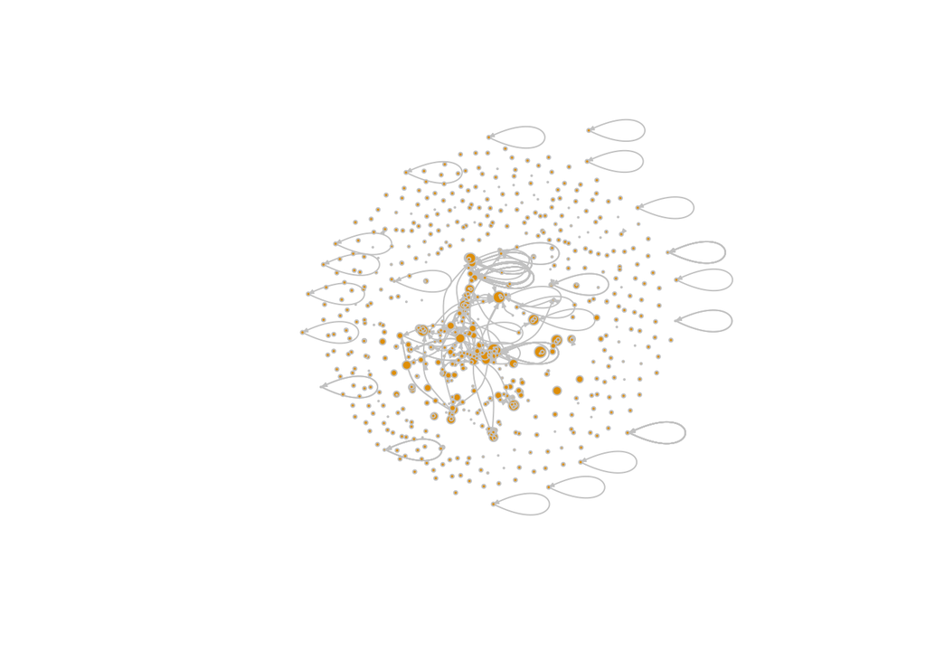

```r
# plot igraph
plot.igraph(net,
            layout=cbind(V(net)$l2,V(net)$l1),
            vertex.size=log(V(net)$indegree),
            vertex.label.color=1,
            vertex.label=NA,
            vertex.color=V(net)$new.color,
            vertex.frame.color=gray(.8),
            edge.color=gray(.8),
            edge.arrow.size=.2,
            edge.curved=TRUE)
```

```r
# Ou esta outra opção mais manual.
# Funcao para visualizar a rede
my.den.plot <- function(l=l,new.color=new.color, ind=ind, legend){
  library(KernSmooth)
  #Numero efectivo de Comunidades
  # ENCG<-round(1/sum(round(table(new.color)/sum(table(new.color)),3)^2),2)
  #
  est <- bkde2D(l, bandwidth=c(10, 10))
  plot(l,cex=log(ind+1)/4, col=new.color, pch=16, xlim=c(-160,140),ylim=c(-140,120), xlab="", ylab="", axes=FALSE)
  contour(est$x1, est$x2, est$fhat,  col = gray(.6), add=TRUE)
  #text(-140,115,paste("ENCG: ",ENCG,sep=""), cex=1, srt=0)
}
# Crie as cores para cada comunidade
# Building a empty containes
temp <- rep(1,length(V(net)$membership))
new.color <- "white"
new.color[V(net)$membership==2] <- "red" ####
new.color[V(net)$membership==3] <- "blue" ####
new.color[V(net)$membership==5] <- "yellow" ####
# Adiciona a nova cor
V(net)$new.color <- new.color
# Plot
#save first
my.den.plot(l=cbind(V(net)$l1,V(net)$l2),new.color=V(net)$new.color, ind=V(net)$indegre, legend =c("Pro-Bolsonaro", "Anti-Bolsonaro"))
```

```
Error in seq.default(a[1L], b[1L], length = M[1L]): 'from' must be a finite number
```

## Hashtags por Comunidade

### Most Popular Hashtags

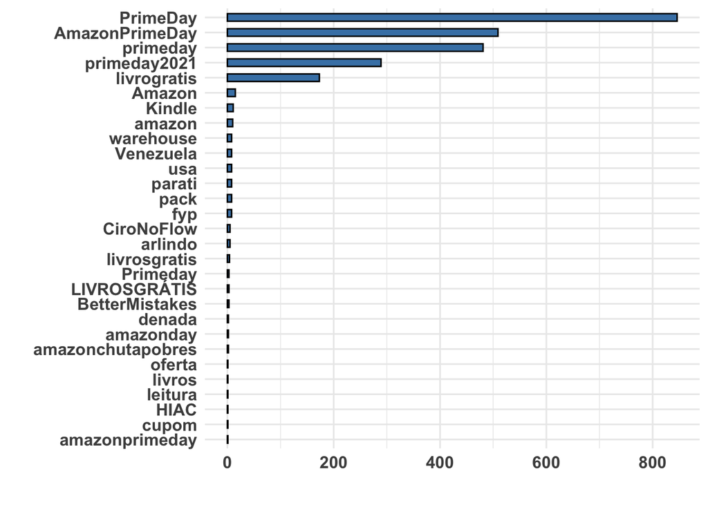

```r
hashtags <- dados_covid_rt %>%
            unnest(hashtags) %>%
            count(hashtags) %>%
            arrange(desc(n)) %>%
            slice(1:30) %>%
            drop_na()

# Contando as hashtags
ggplot(hashtags, aes(x=reorder(hashtags,
                               n),
                     y=n)) +
    geom_histogram(stat="identity", width=.5, color="black",
                   fill="steelblue") +
  coord_flip() +
    xlab("") + ylab("") +
  theme_minimal(base_size = 12) +
  theme(plot.title = element_text(size = 22, face = "bold"),
        axis.title=element_text(size=16),
        axis.text = element_text(size=12, face="bold"))
```

### Hashtags em cada comunidade

```r
# Vamos Coletar as Comunidades
autoridade <- data_frame(name=V(net)$name, membership=V(net)$membership)
# Primeiro, vamos fazer um merge com os dados de comunidade
dados_covid_hash <- dados_covid_rt %>%
                    left_join(autoridade, by=c("screen_name"="name")) %>%
                    unnest(hashtags) %>%
                    drop_na(hashtags)
```

```
Error: All columns in a tibble must be vectors.
x Column `membership` is NULL.
```

```r
table(dados_covid_hash$membership)
```

```
Error in table(dados_covid_hash$membership): object 'dados_covid_hash' not found
```

```r
# Vamos aggrupar por comunidade
hashtags_por_comunidade <- dados_covid_hash %>%
                           filter(membership==2| membership==5) %>%
                           count(membership, hashtags) %>%
                           top_n(10, n)
```

```
Error in filter(., membership == 2 | membership == 5): object 'dados_covid_hash' not found
```

```r
ggplot(hashtags_por_comunidade, aes(x=reorder(hashtags,
                               n),
                     y=n, fill=as.factor(membership))) +
  geom_histogram(stat="identity", width=.5, color="black") +
  coord_flip() +
    xlab("") + ylab("") +
  scale_fill_manual(name="Comunidade", values=c("Red", "Yellow", "steelblue")) +
  theme_minimal(base_size = 16) +
  theme(plot.title = element_text(size = 22, face = "bold"),
        axis.title=element_text(size=12),
        axis.text = element_text(size=12, face="bold"),
        strip.text = element_text(size=16)) +
  facet_wrap(~membership, scale="free")
```

```
Error in ggplot(hashtags_por_comunidade, aes(x = reorder(hashtags, n), : object 'hashtags_por_comunidade' not found
```

## Analizando ativação das mídias na rede

Uma das minhas análises favoritas com dados de twitter vem do [artigo](https://academic.oup.com/joc/article-abstract/68/3/480/4972616) dos meus colegas Natalia Aruguete e Ernesto Calvo. Este artigo discute como comunidades diferentes reagem e falam sobre o mesmo assunto de formas distintas e como esses enquadramentos se espalham nas redes de twitter. Para visualizar isto, vamos fazer um gráfico de redes para cada uma das hashtags e verificar em quais áreas das redes essas hashtags são ativadas

#### Contando o número de menções por nó.

```r
summary(net)
```

```
IGRAPH ec7e669 DN-- 6872 8406 --
+ attr: name (v/c), outdegree (v/n), indegree (v/n), new.color (v/c),
| text (e/c), nameauth (e/c), namehub (e/c), web (e/x), hash (e/x)
```

```r
# Vamos primeiro selecionar as mídias mais ativadas
keynews <- head(sort(table(unlist(E(net)$hash)),decreasing=TRUE),20)
keynews.names <- names(keynews)
N<-length(keynews.names)
count.keynews<- array(0,dim=c(length(E(net)),N))
str(count.keynews)
```

```
 num [1:8406, 1:20] 0 0 0 0 0 0 0 0 0 0 ...
```

```r
# Looping
for(i in 1:N){
  temp<- grepl(keynews.names[i], E(net)$hash, ignore.case = TRUE)
  #temp <- str_match(E(net)$text,'Arangur[A-Za-z]+[A-Za-z0-9_]+')
  count.keynews[temp==TRUE,i]<-1
  Sys.sleep(0.1)
  }
# Setting the names of the media
colnames(count.keynews)<- keynews.names
head(count.keynews)
```

```
     PrimeDay AmazonPrimeDay primeday primeday2021 livrogratis Amazon Kindle
[1,]        0              0        0            0           0      0      0
[2,]        0              0        0            0           0      0      0
[3,]        0              0        0            0           0      0      0
[4,]        0              0        0            0           0      0      0
[5,]        0              0        0            0           0      0      0
[6,]        0              0        0            0           0      0      0
     amazon fyp pack parati usa Venezuela warehouse arlindo CiroNoFlow
[1,]      0   0    0      0   0         0         0       0          0
[2,]      0   0    0      0   0         0         0       0          0
[3,]      0   0    0      0   0         0         0       0          0
[4,]      0   0    0      0   0         0         0       0          0
[5,]      0   0    0      0   0         0         0       0          0
[6,]      0   0    0      0   0         0         0       0          0
     livrosgratis BetterMistakes LIVROSGRÁTIS Primeday
[1,]            0              0            0        0
[2,]            0              0            0        0
[3,]            0              0            0        0
[4,]            0              0            0        0
[5,]            0              0            0        0
[6,]            0              0            0        0
```

#### Recuperando a matrix de vizinhança da rede.

```r
# Conexoes de Vertices e Edges
# Nao rodar!!!!!!!!
# Vamos recuperar todos os nós e edges que estão ligados uns com os outros.
el <- get.adjedgelist(net, mode="all")
al <- get.adjlist(net, mode="all")
```

#### Função para verificar activação na rede

```r
# Função para detectar ativação entre as conexões em rede.
fomfE<- function(var=var, adjV=adjV,adjE=adjE){
  stemp <- map_dbl(adjE, function(x) sum(var[x]))
  #mstemp <- sapply(adjV, function(x) mean(stemp[x]))
  out<-cbind(stemp)
}
# Cria um container
resultado_hash<- array(0,dim=c(length(V(net)),N))
# Repita para cada uma das hashtags
for(i in 1:N){
  bb<-fomfE(count.keynews[,i],al,el)
  bb[bb[,1]=="NaN"]<-0
  resultado_hash[,i]<- bb[,1]
}
```

```
Error: `.x` must be a vector, not a function
```

```r
class(resultado_hash)
```

```
[1] "matrix" "array"
```

```r
colnames(resultado_hash)<- keynews.names
head(resultado_hash)
```

```
     PrimeDay AmazonPrimeDay primeday primeday2021 livrogratis Amazon Kindle
[1,]        0              0        0            0           0      0      0
[2,]        0              0        0            0           0      0      0
[3,]        0              0        0            0           0      0      0
[4,]        0              0        0            0           0      0      0
[5,]        0              0        0            0           0      0      0
[6,]        0              0        0            0           0      0      0
     amazon fyp pack parati usa Venezuela warehouse arlindo CiroNoFlow
[1,]      0   0    0      0   0         0         0       0          0
[2,]      0   0    0      0   0         0         0       0          0
[3,]      0   0    0      0   0         0         0       0          0
[4,]      0   0    0      0   0         0         0       0          0
[5,]      0   0    0      0   0         0         0       0          0
[6,]      0   0    0      0   0         0         0       0          0
     livrosgratis BetterMistakes LIVROSGRÁTIS Primeday
[1,]            0              0            0        0
[2,]            0              0            0        0
[3,]            0              0            0        0
[4,]            0              0            0        0
[5,]            0              0            0        0
[6,]            0              0            0        0
```

### Visualizando Gráficos de Ativação

```r
# all
my.den.plot(l=cbind(V(net)$l1,V(net)$l2),new.color=V(net)$new.color, ind=V(net)$indegre, legend =c("Bolsonaro", "Anti-Bolsonaro"))
```

```
Error in seq.default(a[1L], b[1L], length = M[1L]): 'from' must be a finite number
```

[figure not shown]

```r
# Hashtag
plot(V(net)$l1,V(net)$l2,pch=16,
       col=V(net)$new.color,
       cex=log(resultado_hash[,1]+1),
       xlim=c(-50,150),ylim=c(-50,150), xlab="", ylab="",
       main=colnames(resultado_hash)[1], cex.main=1)
```

[figure not shown]

```r
# Hashtag
plot(V(net)$l1,V(net)$l2,pch=16,
       col=V(net)$new.color,
      cex=log(resultado_hash[,16]),
       xlim=c(-50,100),ylim=c(-50,100), xlab="", ylab="",
       main=colnames(resultado_hash)[16], cex.main=1)
```

[output not shown]

```r
#save.image(file="~/Dropbox/SICSS_Rio/materials/materials/tutorial_Dapp_twitter/tutorial_twitter.RData")
```

```r
# include_graphics("Embedded_News_Bolsonaro_more_rep.png")
# include_graphics("Embedded_News_Bolsonaro_less_rep.png")
```